# Lab 7 & 8 Notebook

### DATA: state_cor (Download it from Canvas)

##### 1. a. Pearon’s R

Are Median family income and % of population with college degree correlated?

```r
# get rid of scientific notation
options(scipen=999)
# outputs correlation coefficient between mdfaminc and collgrad
cor(states_cor$MDFAMINC, states_cor$COLLGRAD, method="pearson", use="complete.obs")
```

```
[1] 0.7836843
```

```r
# give us the p - value, is it significant?
cor.test(states_cor$MDFAMINC, states_cor$COLLGRAD)
```

```
    Pearson's product-moment correlation

data:  states_cor$MDFAMINC and states_cor$COLLGRAD
t = 8.741, df = 48, p-value = 0.00000000001711
alternative hypothesis: true correlation is not equal to 0
95 percent confidence interval:
 0.6463235 0.8718496
sample estimates:
      cor
0.7836843
```

```r
# What does R squared tell us?
CE <- cor(states_cor$MDFAMINC, states_cor$COLLGRAD, method="pearson", use="complete.obs")
##r-squared value
CE^2
```

```
[1] 0.6141611
```

61.42% of variation in median family income is explained by % of population with college degree.

##### 1. b. Correlation Matrix

What if we want to look at correlations across all of the variables in the dataset?

##### First we need to remove variables that do not have numeric values

```r
install.packages('dplyr')
library(dplyr)
#remove variables State and Region from dataset states_cor and create new dataset states_ce
states_ce <- select(states_cor, -STATE, -REGION)
```

Or

```r
states_cor$STATE <- NULL
states_cor$REGION <- NULL
```

###### Now we can continue our analysis. First we name the correlation matrix.

```r
corrmatrix <- cor(states_ce, use="complete.obs")
View(corrmatrix)
```

##### 1. c. Correlation Matrix Visualization

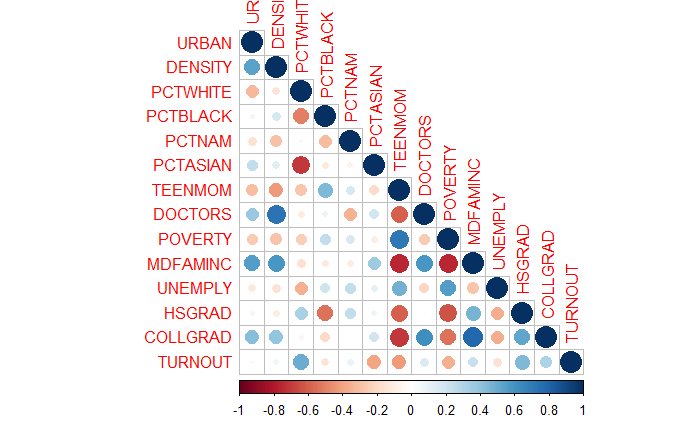

##### 2. Regression

General syntax:

```r
#lm = linear model
# simple regression. y is the dependent variable, x is the independent variable.
lm(y ~ x, data = "the name of dataset")

# multiple regression. x1, x2..xk are all the independent variables.
lm(y ~ x1 + x2 + x3 + ... + xk, data = dataset)
```

##### 2. a. Unadjusted regression / Simple Regression

```r
summary(regression_mdfaminc_collgrad)
```

```
Call:
lm(formula = MDFAMINC ~ COLLGRAD, data = states_cor)

Residuals:
    Min      1Q  Median      3Q     Max
-8408.1 -2742.3  -873.2  2633.6 10203.9

Coefficients:
            Estimate Std. Error t value        Pr(>|t|)
(Intercept)  15817.4     3846.5   4.112        0.000153 ***
COLLGRAD      1329.2      152.1   8.741 0.0000000000171 ***
---
Signif. codes:  0 *** 0.001 ** 0.01 * 0.05 . 0.1   1

Residual standard error: 4590 on 48 degrees of freedom
Multiple R-squared:  0.6142,    Adjusted R-squared:  0.6061
F-statistic:  76.4 on 1 and 48 DF,  p-value: 0.00000000001711
```

##### 2. b. Adjusted impact model / Multiple Regression

```r
summary(regression_2)
```

```
Call:
lm(formula = MDFAMINC ~ COLLGRAD + URBAN + DENSITY + TEENMOM +
    DOCTORS + HSGRAD, data = states_cor)

Residuals:
    Min      1Q  Median      3Q     Max
-5698.9 -2389.7  -344.5  2308.2  9415.6

Coefficients:
             Estimate Std. Error t value Pr(>|t|)
(Intercept) 27250.845  21847.118   1.247  0.21902
COLLGRAD      721.085    211.953   3.402  0.00146 **
URBAN          76.113     42.688   1.783  0.08165 .
DENSITY         9.557      3.420   2.795  0.00773 **
TEENMOM      -798.936    318.193  -2.511  0.01588 *
DOCTORS       -20.904     17.763  -1.177  0.24574
HSGRAD        133.526    217.155   0.615  0.54187
---
Signif. codes:  0 *** 0.001 ** 0.01 * 0.05 . 0.1   1

Residual standard error: 3562 on 43 degrees of freedom
Multiple R-squared:  0.7918,    Adjusted R-squared:  0.7628
F-statistic: 27.26 on 6 and 43 DF,  p-value: 0.0000000000003759
```

##### 2.c. standardized coefficients

general syntax

lm(scale(y) ~ scale(x1) + scale(x2) + â¦.scale(xk), data = dataset name) # y is the dependent variable and x1 ~ xk are all the independent variables.

```r
lm(scale(MDFAMINC) ~ scale(COLLGRAD) + scale(URBAN) + scale(DENSITY) + scale(TEENMOM) + scale(DOCTORS) + scale(HSGRAD), data = states_cor)
```

##### Advanced: 2.d. ‘sjPlot’ and ‘Stargazer’ packages in showing a better format of the regression output

```r
install.packages("sjPlot")
install.packages("stargazer")

library(sjPlot)
library(stargazer)
```

```r
#Here is the unadjusted regression model output using the `sjPlot` package.

sjt.lm(regression_1,
       show.header = TRUE,
       p.numeric = FALSE,
       show.se = TRUE,
       show.fstat = TRUE,
       string.est = "Estimate",
       string.ci = "Conf. Int.",
       string.dv = "Unadjusted Regression Model",
       depvar.labels = c("Median family income"),
       pred.labels = c("% of population with college degree"))
```

```r
#Here is the adjusted regression model output using the `sjPlot` package
sjt.lm(regression_2,
       show.header = TRUE,
       p.numeric = FALSE,
       show.se = TRUE,
       digits.se = 3,
       show.fstat = TRUE,
       string.est = "Estimate",
       string.ci = "Conf. Int.",
       string.dv = "Adjusted Regression Model",
       depvar.labels = c("Median family income"),
       pred.labels = c("% of population with college degree", "% of population urban", "DensityPopulation per square mile",
                       "% of all births to teen moms", "Number of Drs per 100,000 population", "% of population with HS degree"))
```

```r
#3. Showing the unadjusted and adjusted regression results side by side

#stargazer package
stargazer(regression_1, regression_2, title="Regression Results", dep.var.labels=c("Median family income"), type="text")

#sjPlot package:
sjt.lm(regression_1, regression_2,
       show.header = TRUE,
       p.numeric = FALSE,
       show.se = TRUE,
       digits.se = 3,
       show.fstat = TRUE,
       group.pred = FALSE,
       string.est = "Estimate",
       string.ci = "Conf. Int.",
       string.dv = "Regression Results",
       depvar.labels = c("Unadjusted Regression Model", "Adjusted Regression Model"),
       pred.labels = c("% of population with college degree", "% of population urban", "DensityPopulation per square mile",
                       "% of all births to teen moms", "Number of Drs per 100,000 population", "% of population with HS degree"))
```

# Assignment

Data frame for this assignment: empdat_cor (download from Canvas)

##### Part I Correlation

1. What is the appropriate measure(s) of association/correlation for current salary and education? Why?
2. Generate the appropriate measures(s) of association/correlation for current salary and education. Is the relationship significant? Why?
3. Choose one of the three visualization plots to show the correlation matrix for all the variables in the dataset empdat_cor. Which two variables have the strongest correlation relationship?

##### Part II Simple Regression

1. Generate and interpret a simple regression model for the relationship between current salary and age. Using the âsjPlotâ package to show the regression output.
1. Show your regression model output.
2. How much variance in salary can be explained by age?
3. Is age a significant predictor of salary? How do you know?
4. If someoneâs age increased by one year, by how much would you expect their salary to change?
5. Is the model significant? Why?
6. Speculate on the nature of the relationship between age and salary in this dataset.

Submit to Canvas: your answers to these questions AND the R code you used to get the answers.